# Activity Prediction

## Loading and Preprocessing the Data

```r
dat <- read_csv("pml-training.csv", na = c("", "NA", "#DIV/0!"))
test <- read.csv("pml-testing.csv", na = c("", "NA", "#DIV/0!"))

dat <- dat[, -c(1:7, nearZeroVar(dat))]
```

We load the two datasets and drop columns from the training set that are not useful for prediction. To be precise, we drop the first seven columns. (The first one is just a serial number, the other six exist only to uniquely identify the observation. They have no discriminating value.) We also drop the columns with near zero variance, those with very few unique values and those with a single dominating value. We now investigate the number of NA values in our data.

```r
dat %>% mutate_all(is.na) %>% summarise_all(sum) %>% pivot_longer(1:118, names_to="var", values_to="na_count") %>% arrange(desc(na_count)) %>% pull(na_count)
```

```
##   [1] 19301 19301 19300 19300 19300 19299 19296 19296 19294 19293 19248 19248
##  [13] 19227 19227 19226 19226 19226 19225 19221 19221 19221 19220 19218 19217
##  [25] 19216 19216 19216 19216 19216 19216 19216 19216 19216 19216 19216 19216
##  [37] 19216 19216 19216 19216 19216 19216 19216 19216 19216 19216 19216 19216
##  [49] 19216 19216 19216 19216 19216 19216 19216 19216 19216 19216 19216 19216
##  [61] 19216 19216 19216 19216 19216     0     0     0     0     0     0     0
##  [73]     0     0     0     0     0     0     0     0     0     0     0     0
##  [85]     0     0     0     0     0     0     0     0     0     0     0     0
##  [97]     0     0     0     0     0     0     0     0     0     0     0     0
## [109]     0     0     0     0     0     0     0     0     0     0
```

We can see the NA distribution in the data is very bimodal. Either most of the column is NA or none of it is. Hence, we can safely drop all NA columns without losing any information. We also partition the data into a 60-40 training and dev set. We will train the three different models on the training set: Decision Trees, Random Forests and Boosting.

```r
dat <- dat %>% select_if(~all(!is.na(.)))

train.idx <- createDataPartition(dat$classe, p = 0.6, list = FALSE)[, 1]
train <- dat[train.idx, ]
dev <- dat[-train.idx, ]
```

## Decision Tree

```r
model.tree <- rpart(classe ~ ., train, method = "class")

predictions.tree <- predict(model.tree, dev, type="class")

matrix.tree <- confusionMatrix(predictions.tree, as.factor(dev$classe))
matrix.tree
```

```
## Confusion Matrix and Statistics
##
##           Reference
## Prediction    A    B    C    D    E
##          A 1938  290   29  118   41
##          B   59  914  172   87  147
##          C  114  160 1104  228  153
##          D   49   63   47  795  115
##          E   72   91   16   58  986
##
## Overall Statistics
##
##                Accuracy : 0.7312
##                  95% CI : (0.7212, 0.741)
##     No Information Rate : 0.2845
##     P-Value [Acc > NIR] : < 2.2e-16
##
##                   Kappa : 0.659
##
##  Mcnemar's Test P-Value : < 2.2e-16
##
## Statistics by Class:
##
##                      Class: A Class: B Class: C Class: D Class: E
## Sensitivity            0.8683   0.6021   0.8070   0.6182   0.6838
## Specificity            0.9149   0.9265   0.8989   0.9582   0.9630
## Pos Pred Value         0.8022   0.6628   0.6276   0.7437   0.8062
## Neg Pred Value         0.9459   0.9066   0.9566   0.9275   0.9311
## Prevalence             0.2845   0.1935   0.1744   0.1639   0.1838
## Detection Rate         0.2470   0.1165   0.1407   0.1013   0.1257
## Detection Prevalence   0.3079   0.1758   0.2242   0.1362   0.1559
## Balanced Accuracy      0.8916   0.7643   0.8530   0.7882   0.8234
```

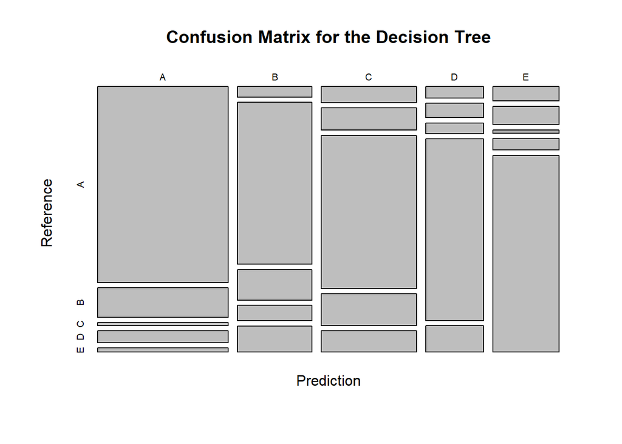

```r
plot(matrix.tree$table, main = "Confusion Matrix for the Decision Tree")
```

## Random Forests

```r
control.rand_for <- trainControl(method = "cv", number = 10, verboseIter = FALSE)
model.rand_for <- train(classe ~ ., data = train, method = "rf", trControl=control.rand_for)

predictions.rand_for <- predict(model.rand_for, dev, type = "raw")

matrix.rand_for <- confusionMatrix(predictions.rand_for, as.factor(dev$classe))
```

```r
matrix.rand_for
```

```
## Confusion Matrix and Statistics
##
##           Reference
## Prediction    A    B    C    D    E
##          A 2231   12    0    0    0
##          B    0 1504    6    1    1
##          C    0    2 1358   19    6
##          D    0    0    4 1265    3
##          E    1    0    0    1 1432
##
## Overall Statistics
##
##                Accuracy : 0.9929
##                  95% CI : (0.9907, 0.9946)
##     No Information Rate : 0.2845
##     P-Value [Acc > NIR] : < 2.2e-16
##
##                   Kappa : 0.991
##
##  Mcnemar's Test P-Value : NA
##
## Statistics by Class:
##
##                      Class: A Class: B Class: C Class: D Class: E
## Sensitivity            0.9996   0.9908   0.9927   0.9837   0.9931
## Specificity            0.9979   0.9987   0.9958   0.9989   0.9997
## Pos Pred Value         0.9947   0.9947   0.9805   0.9945   0.9986
## Neg Pred Value         0.9998   0.9978   0.9985   0.9968   0.9984
## Prevalence             0.2845   0.1935   0.1744   0.1639   0.1838
## Detection Rate         0.2843   0.1917   0.1731   0.1612   0.1825
## Detection Prevalence   0.2859   0.1927   0.1765   0.1621   0.1828
## Balanced Accuracy      0.9987   0.9948   0.9943   0.9913   0.9964
```

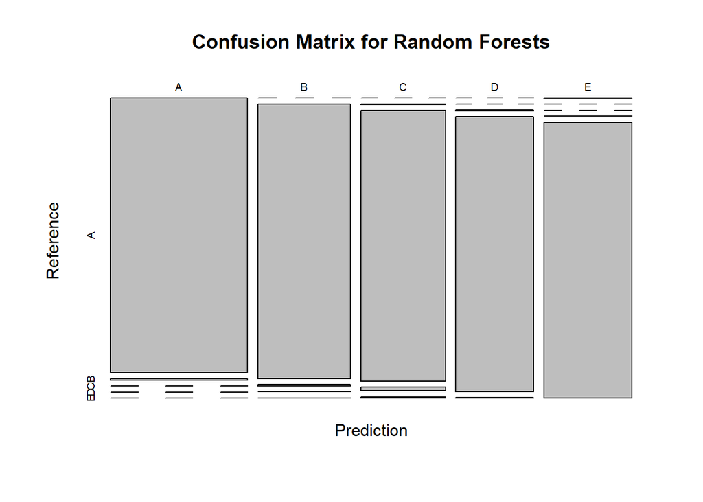

```r
plot(matrix.rand_for$table, main = "Confusion Matrix for Random Forests")
```

Random Forests perform exceptionally well achieving almost 100% accuracy on our hold-out set. We have used ordinary cross validation (size = 10) to train the model.

## Boosting

```r
control.gbm <- trainControl(method = "cv", number = 10, verboseIter = FALSE)
model.gbm <- train(classe ~ ., data = train, method = "gbm", trControl=control.gbm)

predictions.gbm <- predict(model.gbm, dev, type = "raw")

matrix.gbm <- confusionMatrix(predictions.gbm, as.factor(dev$classe))
```

```r
matrix.gbm
```

```
## Confusion Matrix and Statistics
##
##           Reference
## Prediction    A    B    C    D    E
##          A 2193   49    0    2    8
##          B   19 1436   42    6   25
##          C   11   30 1305   47   18
##          D    7    2   19 1223    9
##          E    2    1    2    8 1382
##
## Overall Statistics
##
##                Accuracy : 0.9609
##                  95% CI : (0.9563, 0.9651)
##     No Information Rate : 0.2845
##     P-Value [Acc > NIR] : < 2.2e-16
##
##                   Kappa : 0.9505
##
##  Mcnemar's Test P-Value : 2.544e-13
##
## Statistics by Class:
##
##                      Class: A Class: B Class: C Class: D Class: E
## Sensitivity            0.9825   0.9460   0.9539   0.9510   0.9584
## Specificity            0.9895   0.9855   0.9836   0.9944   0.9980
## Pos Pred Value         0.9738   0.9398   0.9249   0.9706   0.9907
## Neg Pred Value         0.9930   0.9870   0.9902   0.9904   0.9907
## Prevalence             0.2845   0.1935   0.1744   0.1639   0.1838
## Detection Rate         0.2795   0.1830   0.1663   0.1559   0.1761
## Detection Prevalence   0.2870   0.1947   0.1798   0.1606   0.1778
## Balanced Accuracy      0.9860   0.9657   0.9688   0.9727   0.9782
```

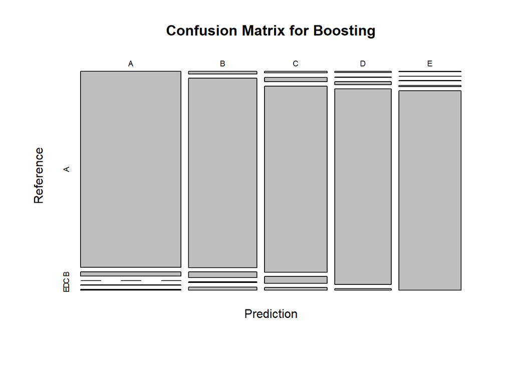

```r
plot(matrix.gbm$table, main = "Confusion Matrix for Boosting")
```

Boosting is significantly better than a decision tree but falls just short of a model based on random forests. We have used ordinary cross validation (size = 10) to train the model.

## Predictions

Finally, we use the Random Forests model to predict the 20 quiz questions:

```r
predict(model.rand_for, newdata = test)
```

```
##  [1] B A B A A E D B A A B C B A E E A B B B
## Levels: A B C D E
```